**Machine Learning for Mechanical Engineering**  
**Homework 04 - Solution**

Prof. Seungchul Lee  
http://iai.postech.ac.kr/  
Industrial AI Lab at POSTECH

# Problem 1

Suppose you receive the binary signal. The signal is corrupted with noises while transmitting through channels. We want to get rid of noise from the original signal through the $L_1$ optimization. The mathematical problem statement is given:

$$ \begin{array}{Icr}\begin{align*} y = x + \omega\\ x \in \{ 0, 1 \}\\ \omega \text{ is noise} \end{align*}\end{array} \quad \Longrightarrow \begin{array}{I} \quad \text{Recover original signal } x \text{ from corrupted signal } y \end{array} $$

### Step 1. Data generation

(a) First, generate the original signal of 200 data points as shown in the below figure. This can be simply done using ones and zeros commands in Python.

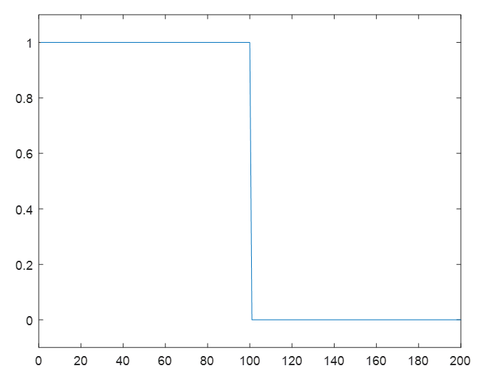

```python
# Write your code here
#
```

(b) Next, corrupt the original signal with Gaussian noise. This can be done using randn command in Python. One of realizations of the corrupted signal will be given:

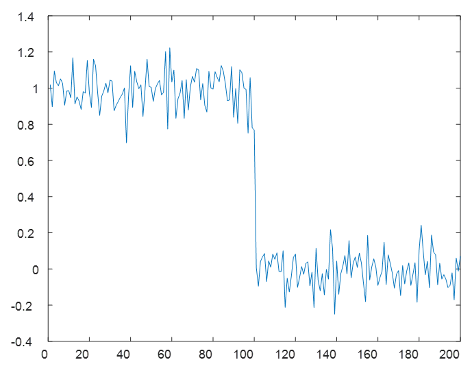

```python
# Write your code here
#
```

### Step 2. $L_1$ optimization

Note that the signal is sparse (in a sense of frequency domain). Therefore we can apply the $L_1$ optimization. We will optimize the $L_1$ loss function with the $L_2$ constraints.

(c) Plot the reconstructed signal. In addition, by changing $\beta$ in the lecture slide, explain how $\beta$ affects in an optimization process. One of reconstructed signal with a proper value of $\beta$ is shown below:

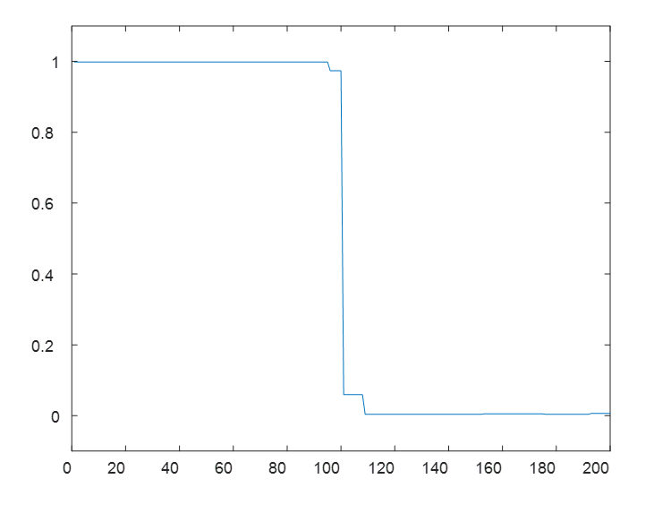

```python
# Write your code here
#
```

# Solution 1

(a) First, generate the original signal of 200 data points as shown in the below figure. This can be simply done using ones and zeros commands in Python.

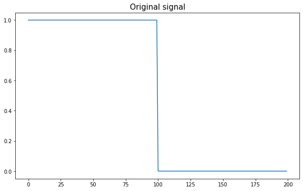

```python
import numpy as np
import cvxpy as cvx
import matplotlib.pyplot as plt
%matplotlib inline

ones = np.ones([100,1])
zeros = np.zeros([100, 1])

x = np.vstack([ones, zeros])
plt.figure(figsize = (10, 6))
plt.plot(x)
plt.title('Original signal', fontsize=15)
plt.show()
```

(b) Next, corrupt the original signal with Gaussian noise. This can be done using randn command in Python. One of realizations of the corrupted signal will be given:

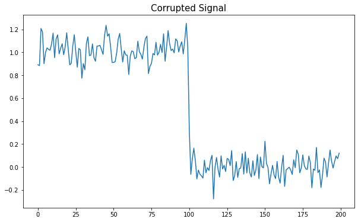

```python
x_cor = x + 0.1*np.random.randn(200, 1)

plt.figure(figsize = (10, 6))
plt.plot(x_cor)
plt.title('Corrupted Signal', fontsize=15)
plt.show()
```

(c) Plot the reconstructed signal. In addition, by changing the beta, explain how beta affects in an optimization process. One of reconstructed signal with a proper value of beta is shown below:

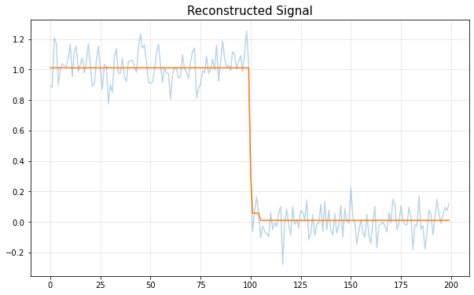

```python
# Step 2
beta = 1.3
x_hat = cvx.Variable([200, 1])
obj = cvx.Minimize(cvx.norm(x_hat[1:200] - x_hat[0:199], 1))
const = [cvx.norm(x_hat - x_cor, 2) <= beta]
prob = cvx.Problem(obj, const)
result = prob.solve()

x_hat = np.asarray(x_hat.value)

plt.figure(figsize = (10, 6))
plt.plot(x_cor, alpha = 0.3)
plt.plot(x_hat)
plt.title('Reconstructed Signal', fontsize=15)
plt.grid(alpha = 0.3)
plt.show()
```

# Problem 5

We have learned the total variation with the following image example.

[Download data](https://www.dropbox.com/s/rly8ryfhcswja3q/dog.jpg?dl=1)

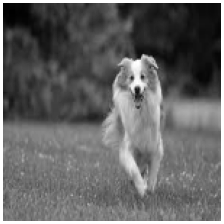

```python
import cv2
import matplotlib.pyplot as plt
imbw = cv2.imread('.\image_files\dog.jpg', 0)

row = 150
col = 150
resized_imbw = cv2.resize(imbw, (row, col))

plt.figure(figsize = (8,8))
plt.imshow(resized_imbw, 'gray')
plt.axis('off')
plt.show()
```

(a) Apply $L_1$ norm regularization to the image by solving

$$ \min\; \left\{ \lVert x-x_{cor}\rVert_2^2 + \mu \lVert Dx \rVert_1 \right\}$$

```python
n = row*col
imbws = resized_imbw.reshape(-1, 1)

mu = 100

## your code here
#
```

(b) However, the output image is not exactly what we want since the 2D image (or matrix) is flattened to make it an 1D column vector (or signal). We now consider 2D images. Apply a similar method like (a) by solving the following objective function.

$$ \text{minimize} \quad \sum_{i=1}^{n} \sum_{j=1}^{n} \left( x_{i,j} - x_{i,j}^{cor} \right)^2 + \mu \left[ \sum_{i=1}^{n-1} \sum_{j=1}^{n} \lvert x_{i+1,j}-x_{i,j} \rvert + \sum_{i=1}^{n}\sum_{j=1}^{n-1} \lvert x_{i,j+1}-x_{i,j} \rvert \right]$$

- Hint: Use $\text{col} \times \text{row}$ Variable to solve this cvx problem

```python
mu = 1500

x = cvx.Variable([row,col])

## your code here
#
```

# Solution 5

(a) Apply $L_1$ norm regularization to the image by solving

$$ \min\; \left\{ \lVert x-x_{cor}\rVert_2^2 + \mu \lVert Dx \rVert_1 \right\}$$

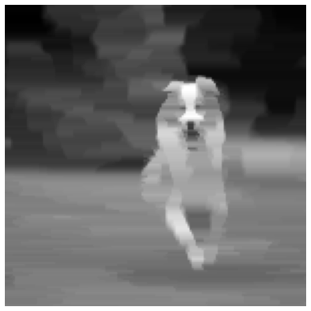

```python
import cvxpy as cvx
n = row*col
imbws = resized_imbw.reshape(-1, 1)

beta = 1500

x = cvx.Variable([n,1])
obj = cvx.Minimize(cvx.norm(x[1:n] - x[0:n-1],1))
const = [cvx.norm(x - imbws,2) <= beta]
prob = cvx.Problem(obj, const).solve()

imbwr = x.value.reshape(row, col)

plt.figure(figsize = (8,8))
plt.imshow(imbwr,'gray')
plt.axis('off')
plt.show()
```

(b) However, the output image is not exactly what we want since the 2D image (or matrix) is flattened to make it an 1D column vector (or signal). We now consider 2D images. Apply a similar method like (a) by solving the following objective function.

$$ \text{minimize} \quad \sum_{i=1}^{n} \sum_{j=1}^{n} \left( x_{i,j} - x_{i,j}^{cor} \right)^2 + \mu \left[ \sum_{i=1}^{n-1} \sum_{j=1}^{n} \lvert x_{i+1,j}-x_{i,j} \rvert + \sum_{i=1}^{n}\sum_{j=1}^{n-1} \lvert x_{i,j+1}-x_{i,j} \rvert \right]$$

- Hint: Use $\text{col} \times \text{row}$ Variable to solve this cvx problem

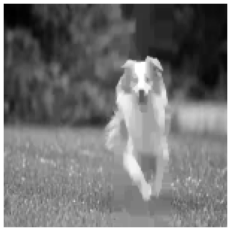

```python
mu = 1500

x = cvx.Variable([row,col])
obj = cvx.Minimize(cvx.sum_squares(x - resized_imbw) +
                   mu*(cvx.norm(x[:,1:] - x[:,:row-1], 1) + cvx.norm(x[1:,:] - x[:col-1,:], 1)))
prob = cvx.Problem(obj).solve()

imbwr = x.value.reshape(row, col)
plt.figure(figsize = (8,8))
plt.imshow(imbwr,'gray')
plt.axis('off')
plt.show()
```

# Problem 7

Suppose we have a linear regression model with two weights and no bias term:

$$y = \omega_1 x_1 + \omega_2 x_2$$

and the usual loss function $\ell(y,\hat y) = \frac{1}{2}(y− \hat y)^2$ and cost $\mathcal{C}(\omega_1, \omega_2) = \frac{1}{m} \sum_{i}\ell(y^{(i)},\hat y ^{(i)})$. Suppose we have a training set consisting of $m = 3$ examples:

- $x^{(1)} = [1,0]^T,\; y^{(1)} = 2$
- $x^{(2)} = [0,1]^T,\; y^{(2)} = 2$
- $x^{(3)} = [\sqrt{3},0]^T,\; y^{(3)} = 0$

Let’s sketch one of the contours in weight space.

(a) [3pt] Write the cost in the form

$$\mathcal{C} = c_1 (\omega_1 - d_1)^2 + c_2 (\omega_2 - d_2)^2 + c_0$$

(b) [3pt] Since $c_1, c_2 > 0$, this corresponds to an axis-aligned ellipse of $\omega_1$ and $\omega_2$. Sketch the ellipse by hands for $\mathcal{C} = 4$. Label the center and radii of the ellipse.

**(a)** [3pt]

$$\begin{align} \mathcal{C}(\omega_1, \omega_2) & = \frac{1}{m} \sum_{i}\ell(y^{(i)},t^{(i)}) \\ & = \frac{1}{3}\left[\ell(y^{(1)},t^{(1)})+\ell(y^{(2)},t^{(2)}) +\ell(y^{(3)},t^{(3)}) \right] \\ & = \frac{1}{3}\left[\frac{1}{2}\left(\omega_1-2\right)^2+\frac{1}{2}\left(\omega_2-2\right)^2+\frac{1}{2}\left(\sqrt{3}\omega_1\right)^2\right]\\ & = \frac{1}{6}\left[\omega_1^2-4\omega_1+4+3\omega_1^2+\left(\omega_2-2\right)^2\right]\\ & = \frac{1}{6}\left[\left(2\omega_1-1\right)^2+\left(\omega_2-2\right)^2 + 3 \right] \\ & = \frac{1}{6}4\left(\omega_1-\frac{1}{2}\right)^2+\frac{1}{6}\left(\omega_2-2\right)^2 + \frac{3}{6} \\ & = \frac{2}{3}\left(\omega_1-\frac{1}{2}\right)^2+\frac{1}{6}\left(\omega_2-2\right)^2 + \frac{1}{2} \end{align}$$

$$ \therefore c_1 = \frac{2}{3},\; c_2 = \frac{1}{6},\; c_0=\frac{1}{2},\; d_1=\frac{1}{2},\; d_2=2 $$

**(b)** [3pt]

$$ \begin{align} \mathcal{C} = \frac{2}{3}&\left(\omega_1-\frac{1}{2}\right)^2+\frac{1}{6}\left(\omega_2-2\right)^2 + \frac{1}{2} = 4 \\ \implies & \frac{\left(\omega_1-\frac{1}{2}\right)^2}{3/2}+\frac{\left(\omega_2-2\right)^2}{6} = \frac{7}{2} \\ & \frac{\left(\omega_1-\frac{1}{2}\right)^2}{21/4}+\frac{\left(\omega_2-2\right)^2}{21} = 1 \end{align}$$

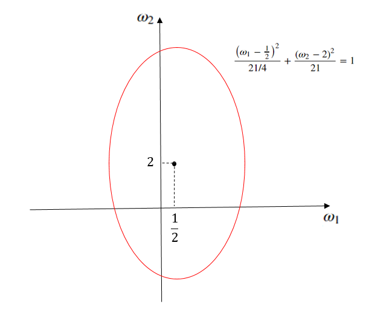

$$ \text{Center }= \left(\frac{1}{2},\; 2\right) \\ \text{long radius }= \sqrt{21},\quad \text{short radius }= \frac{\sqrt{21}}{2} $$

# Problem 8

This problem is motivated by the response surface methodology. The response surface methodology (RSM) is a collection of statistical and mathematical techniques used for the purpose of

- Setting up a series of experiments (design) for adequate predictions of a response y.
- Fitting a hypothesized (empirical) model to data obtained under the chosen design.
- Determining optimum conditions on the model's input (control) variables that lead to maximum or minimum response within a region of interest.

(a) [3pt] Find and plot an approximated curve of the given data points below in Python using your non-linear regression algorithm. Use the polynomial basis functions with a degree of 9. Your curve should become non-convex function with several local minima. Do not worry about overfitting.

$$\hat y = \theta_0 + \theta_1 x + \cdots + \theta_9 x^9$$

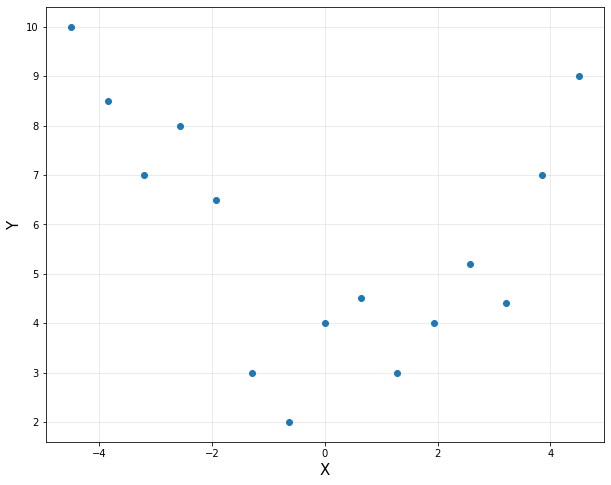

```python
import numpy as np
import matplotlib.pyplot as plt
%matplotlib inline

y = np.array([10, 8.5, 7, 8, 6.5, 3, 2, 4, 4.5, 3, 4, 5.2, 4.4, 7, 9])
x = np.linspace(-4.5, 4.5, y.shape[0])

plt.figure(figsize = (10, 8))
plt.plot(x, y, 'o', label = 'Data')
plt.xlabel('X', fontsize = 15)
plt.ylabel('Y', fontsize = 15)
plt.grid(alpha = 0.3)
plt.show()

# code
```

(b) [6pt] Then we like to find the optimal point $x^*$ from the estimated response surface. Find the minimum point by the gradient descent algorithm in this non-convex problem. Remember that there might exist several local minima.

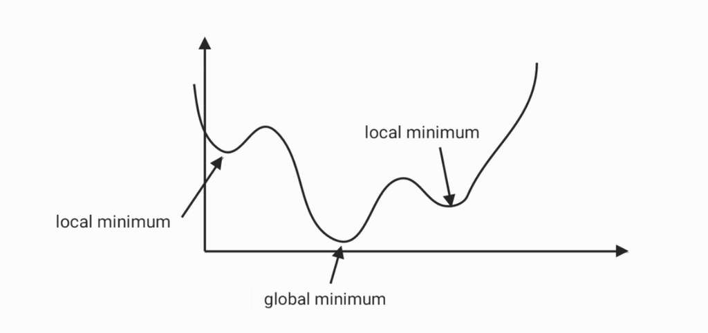

```python
# code
#
```

# Solution 8

This problem is motivated by the response surface methodology. The response surface methodology (RSM) is a collection of statistical and mathematical techniques used for the purpose of

- Setting up a series of experiments (design) for adequate predictions of a response y.
- Fitting a hypothesized (empirical) model to data obtained under the chosen design.
- Determining optimum conditions on the model's input (control) variables that lead to maximum or minimum response within a region of interest.

(a) [3pt] Find and plot an approximated curve of the given data points below in Python using your non-linear regression algorithm. Use the polynomial basis functions with a degree of 9. Your curve should become non-convex function with several local minima. Do not worry about overfitting.

$$\hat y = \theta_0 + \theta_1 x + \cdots + \theta_9 x^9$$

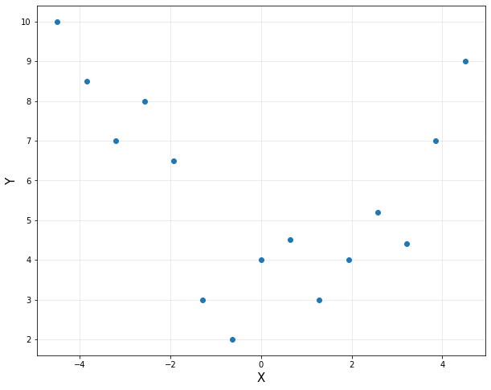

```python
import numpy as np
import matplotlib.pyplot as plt
%matplotlib inline

y = np.array([10, 8.5, 7, 8, 6.5, 3, 2, 4, 4.5, 3, 4, 5.2, 4.4, 7, 9])
x = np.linspace(-4.5, 4.5, y.shape[0])

plt.figure(figsize = (10, 8))
plt.plot(x, y, 'o', label = 'Data')
plt.xlabel('X', fontsize = 15)
plt.ylabel('Y', fontsize = 15)
plt.grid(alpha = 0.3)
plt.show()
```

```
[[ 3.01186721e+00]
 [ 1.59928516e+00]
 [ 6.79333824e-01]
 [-1.06644782e+00]
 [-4.94272985e-02]
 [ 1.64747543e-01]
 [ 1.65074593e-03]
 [-9.75432632e-03]
 [-3.91925321e-06]
 [ 1.98201678e-04]]
```

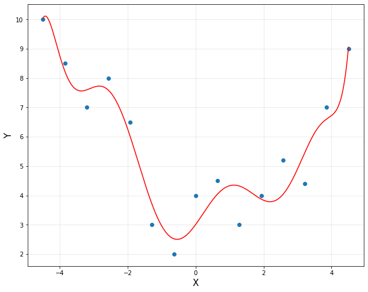

```python
# Write your code here
#
m = np.shape(x)[0]
x = np.reshape(x,(-1,1))
y = np.reshape(y,(-1,1))

X = np.hstack([x**i for i in range(10)])
X = np.asmatrix(X)
y = np.asmatrix(y)

theta = np.ones([10,1])

theta = (X.T*X).I*X.T*y

print(theta)

# Write your code here
#
xp = np.linspace(-4.5, 4.5,1000)
yp = theta[0,0] + theta[1,0]*xp + theta[2,0]*xp**2 + theta[3,0]*xp**3 + \
        theta[4,0]*xp**4 + theta[5,0]*xp**5 + theta[6,0]*xp**6 + theta[7,0]*xp**7 + theta[8,0]*xp**8 + theta[9,0]*xp**9

plt.figure(figsize = (10, 8))
plt.plot(x, y, 'o', label = 'Data')
plt.plot(xp,yp, 'r')
plt.xlabel('X', fontsize = 15)
plt.ylabel('Y', fontsize = 15)
plt.grid(alpha = 0.3)
plt.show()
```

(b) [6pt] Then we like to find the optimal point $x^*$ from the estimated response surface. Find the minimum point by the gradient descent algorithm in this non-convex problem. Remember that there might exist several local minima.

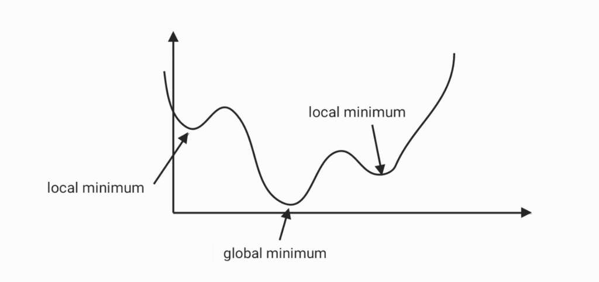

```python
def output(x, theta):
    y = theta[0,0] + theta[1,0]*x + theta[2,0]*x**2 + theta[3,0]*x**3 + \
     theta[4,0]*x**4 + theta[5,0]*x**5 + theta[6,0]*x**6 + theta[7,0]*x**7 + theta[8,0]*x**8 + theta[9,0]*x**9
    return y

alpha = 0.001
y = 20

for i in range(10):
    x = -4.5 + 9*np.random.rand()
    for i in range(1000):
        gradient = 0
        for i in range(9):
            gradient += (i+1)*theta[i+1,0]*x**i

        x = x - alpha*gradient

    result = output(x, theta)
    if (result < y):
        y = result

print('y: ')
print(y)
```

```
y:
2.5025811216084555
```